# Project 1: Explore and Prepare Data - Submitted by GT User: sanne31 (sanne31@gatech.edu)

CSE6242 - Data and Visual Analytics - Summer 2018 Due: Sunday, June 17, 2018 at 11:59 PM UTC-12:00 on T-Square

*Note: This project involves getting data ready for analysis and doing some preliminary investigations. Project 2 will involve modeling and predictions on the same dataset, and will be released at a later date. Both projects will have equal weightage towards your grade. You may reuse some of the preprocessing/analysis steps from Project 1 in Project 2.*

# Data

In this project, you will explore a dataset that contains information about movies, including ratings, budget, gross revenue and other attributes. It was prepared by Dr. Guy Lebanon, and here is his description of the dataset:

> The file [`movies_merged`](https://s3.amazonaws.com/content.udacity-data.com/courses/gt-cs6242/project/movies_merged) contains a dataframe with the same name that has 40K rows and 39 columns. Each row represents a movie title and each column represents a descriptor such as `Title`, `Actors`, and `Budget`. I collected the data by querying IMDbâs API (see [www.omdbapi.com](http://www.omdbapi.com/)) and joining it with a separate dataset of movie budgets and gross earnings (unknown to you). The join key was the movie title. This data is available for personal use, but IMDbâs terms of service do not allow it to be used for commercial purposes or for creating a competing repository.

# Objective

Your goal is to investigate the relationship between the movie descriptors and the box office success of movies, as represented by the variable `Gross`. This task is extremely important as it can help a studio decide which titles to fund for production, how much to bid on produced movies, when to release a title, how much to invest in marketing and PR, etc. This information is most useful before a title is released, but it is still very valuable after the movie is already released to the public (for example it can affect additional marketing spend or how much a studio should negotiate with on-demand streaming companies for âsecond windowâ streaming rights).

# Instructions

When you execute code within the notebook, the results appear beneath the code. Try executing this chunk by clicking the *Run* button within the chunk or by placing your cursor inside it and pressing *Cmd+Shift+Enter*.

```r
x = 1:10
print(x^2)
```

```
 [1]   1   4   9  16  25  36  49  64  81 100
```

Plots appear inline too:

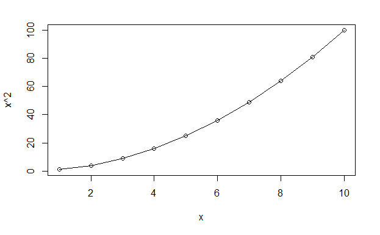

```r
plot(x, x^2, 'o')
```

Please complete all the tasks below by implementing code chunks that have a `TODO` comment in them, running all code chunks so that output and plots are displayed, and typing in answers to each question (**Q:** …) next to/below the corresponding answer prompt (**A:**). Feel free to add code chunks/show additional output to support any of the answers.

When you are done, you will need to submit the final R markdown file (as **pr1.Rmd**) with all code chunks implemented and executed, and all text responses written in. You also need to submit a PDF export of the markdown file (as **pr1.pdf**), which should show your code, output, plots and written responses–this will be your project report. Compress these two files into a single .zip archive and upload it on T-Square.

# Setup

## Load data

Make sure you’ve downloaded the [`movies_merged`](https://s3.amazonaws.com/content.udacity-data.com/courses/gt-cs6242/project/movies_merged) file and it is in the current working directory. Now load it into memory:

```r
load('movies_merged')
cat("Dataset has", dim(movies_merged)[1], "rows and", dim(movies_merged)[2], "columns", end="\n", file="")
```

```
Dataset has 40789 rows and 39 columns
```

This creates an object of the same name (`movies_merged`). For convenience, you can copy it to `df` and start using it:

```r
df = movies_merged
test = movies_merged
cat("Column names:", end="\n", file="")
```

```
Column names:
```

```r
colnames(df)
```

```
 [1] "Title"             "Year"              "Rated"
 [4] "Released"          "Runtime"           "Genre"
 [7] "Director"          "Writer"            "Actors"
[10] "Plot"              "Language"          "Country"
[13] "Awards"            "Poster"            "Metascore"
[16] "imdbRating"        "imdbVotes"         "imdbID"
[19] "Type"              "tomatoMeter"       "tomatoImage"
[22] "tomatoRating"      "tomatoReviews"     "tomatoFresh"
[25] "tomatoRotten"      "tomatoConsensus"   "tomatoUserMeter"
[28] "tomatoUserRating"  "tomatoUserReviews" "tomatoURL"
[31] "DVD"               "BoxOffice"         "Production"
[34] "Website"           "Response"          "Budget"
[37] "Domestic_Gross"    "Gross"             "Date"
```

## Load R packages

Load any R packages that you will need to use. You can come back to this chunk, edit it and re-run to load any additional packages later.

```r
install.packages("NLP",dependencies = TRUE)
install.packages('reshape2')
install.packages("tm")
install.packages("ggplot2")
install.packages("GGally")
install.packages("tidyr")
install.packages("SnowballC")
install.packages("lubridate")
library(ggplot2)
library(GGally)
library(tidyr)
library(NLP)
library(tm)
library(plyr)
library(reshape2)
library(SnowballC)
library(lubridate)
library(stringr)
```

If you are loading any non-standard packages (ones that have not been discussed in class or explicitly allowed for this project), please mention them below. Include any special instructions if they cannot be installed using the regular `install.packages('<pkg name>')` command.

**Non-standard packages used**:

# Tasks

Each task below is worth **10** points, and is meant to be performed sequentially, i.e. do step 2 after you have processed the data as described in step 1. Total points: **100**

Complete each task by implementing code chunks as described by `TODO` comments, and by responding to questions (“**Q**:”) with written answers (“**A**:”). If you are unable to find a meaningful or strong relationship in any of the cases when requested, explain why not by referring to appropriate plots/statistics.

It is okay to handle missing values below by omission, but please omit as little as possible. It is worthwhile to invest in reusable and clear code as you may need to use it or modify it in project 2.

## 1. Remove non-movie rows

The variable `Type` captures whether the row is a movie, a TV series, or a game. Remove all rows from `df` that do not correspond to movies.

```r
# TODO: Remove all rows from df that do not correspond to movies
df2 <- df[df$Type == "movie",]
dim(df2)
```

```
[1] 40000    39
```

**Q**: How many rows are left after removal? *Enter your response below.*

**A**:40000

## 2. Process `Runtime` column

The variable `Runtime` represents the length of the title as a string. Write R code to convert it to a numeric value (in minutes) and replace `df$Runtime` with the new numeric column.

```r
# TODO: Replace df$Runtime with a numeric column containing the runtime in minutes
#NoNarun_time <- df2$Runtime
#NoNarun_time[is.character(NoNarun_time) & NoNarun_time == "N/A"] <- "0 min"
raw_run_time <- df2$Runtime
h_run_time <- as.numeric(gsub(".*?(\\d+) [Hh]r?.*", "\\1", raw_run_time))
```

```
NAs introduced by coercion
```

```r
h_run_time[is.na(h_run_time)] <- 0
m_run_time <- as.numeric(gsub(".*?(\\d+) [Mm]in?.*", "\\1", raw_run_time))
```

```
NAs introduced by coercion
```

```r
m_run_time[is.na(m_run_time)] <- 0
run_time <- (h_run_time * 60) + m_run_time
df2$Runtime <- run_time
typeof(df2$Runtime)
```

```
[1] "double"
```

Now investigate the distribution of `Runtime` values and how it changes over years (variable `Year`, which you can bucket into decades) and in relation to the budget (variable `Budget`). Include any plots that illustrate.

```r
# TODO: Investigate the distribution of Runtime values and how it varies by Year and Budget
summary(df2$Year)
```

```
   Min. 1st Qu.  Median    Mean 3rd Qu.    Max.
   1888    1961    1989    1981    2001    2018
```

```r
summary(df2$Budget)
```

```
     Min.   1st Qu.    Median      Mean   3rd Qu.      Max.      NA's
     1100   5000000  18000000  31661108  40000000 425000000     35442
```

```r
summary(df2$Runtime)
```

```
   Min. 1st Qu.  Median    Mean 3rd Qu.    Max.
   0.00   69.00   90.00   80.26  100.00  873.00
```

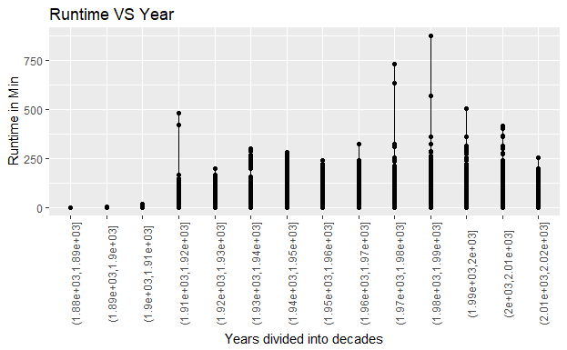

```r
df2$Period = cut(x = df2$Year, breaks = c(1880, seq(1890,2020, by=10)))
ggplot(df2, aes(x = Period, y = Runtime)) + geom_point() + geom_line() +#geom_bar(stat = "identity") +
  theme(axis.text.x = element_text(angle = 90)) + ggtitle("Runtime VS Year") +
  xlab("Years divided into decades") + ylab("Runtime in Min")
```

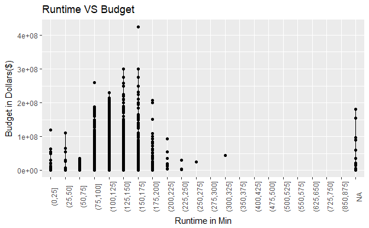

```r
df2$Div_runtime = cut(x = df2$Runtime, breaks = c(0, seq(25,875, by=25)))
ggplot(df2, aes(x = Div_runtime, y = Budget)) + geom_point() + geom_line() +
  theme(axis.text.x = element_text(angle = 90)) + ggtitle("Runtime VS Budget") +xlab("Runtime in Min") + ylab("Budget in Dollars($)")
```

*Feel free to insert additional code chunks as necessary.*

**Q**: Comment on the distribution as well as relationships. Are there any patterns or trends that you can observe?

**A**: It can be observed from both of the graphs that runtime varies greatly with both Year and the Budget.

Taking a look at the plot between Runtime and Year, we can see that it is not a straightforward relationship. It is almost as if the runtime is negligible until 1910 where the runtime increases rather quickly. Thereafter, the runtime appears to be constant during the years until 1970 where it increases again till 1980 and then appears to be dropping gradually indicating that over the course of the next couple years, it can be assumed that the runtime length of films might decrease.

## 3. Encode `Genre` column

The column `Genre` represents a list of genres associated with the movie in a string format. Write code to parse each text string into a binary vector with 1s representing the presence of a genre and 0s the absence, and add it to the dataframe as additional columns. Then remove the original `Genre` column.

For example, if there are a total of 3 genres: Drama, Comedy, and Action, a movie that is both Action and Comedy should be represented by a binary vector <0, 1, 1>. Note that you need to first compile a dictionary of all possible genres and then figure out which movie has which genres (you can use the R `tm` package to create the dictionary).

```r
# TODO: Replace Genre with a collection of binary columns
summary(df2$Genre)
```

```
   Length     Class      Mode
    40000 character character
```

```r
View(df2)
genre_dictionary <- unique(unlist(strsplit(df2$Genre, ", ")))
genre = data.frame(matrix(nrow = nrow(df2), ncol = length(genre_dictionary)))
colnames(genre) = genre_dictionary
genre[] = 0
for (x in genre_dictionary)
{
  genre[grep(x, df2[, "Genre"]), x] = 1
  #here we compare each and every genre value to the original dataset and the dictionary,
  #searching for x in df2 dataframe$genre, will put 1 if it encounters any of the genres in genre data frame or will put a zero.
  #total number of genres is 29, so there will be 29 extra rows.
}
new_genre = cbind(df2, genre)
#final step is to attach the set of binary columns to the original dataframe
```

Plot the relative proportions of movies having the top 10 most common genres.

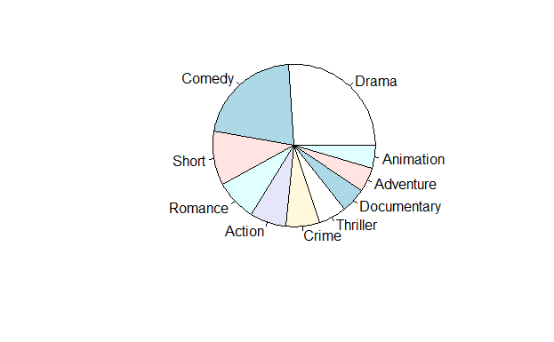

```r
# TODO: Select movies from top 10 most common genres and plot their relative proportions
metrics = colSums(genre)
sorted = sort(metrics, decreasing = TRUE)
#relative proportions = total count / number of rows
#taking top 10 genres
rel_prop = (sorted[1:10]) / nrow(df2)
#rel_prop <- data.frame(rel_prop)
pie(rel_prop)
```

Examine how the distribution of `Runtime` changes across genres for the top 10 most common genres.

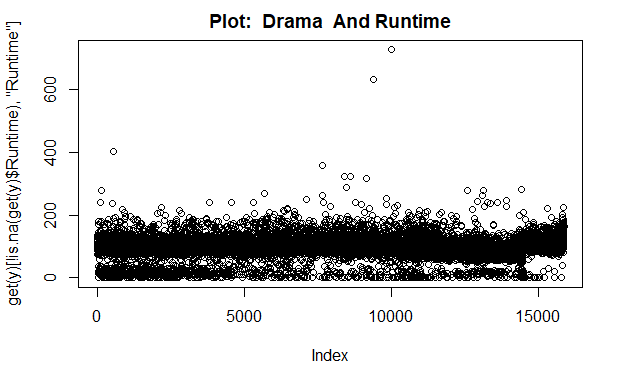

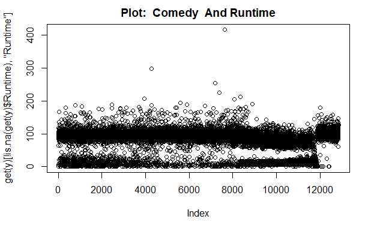

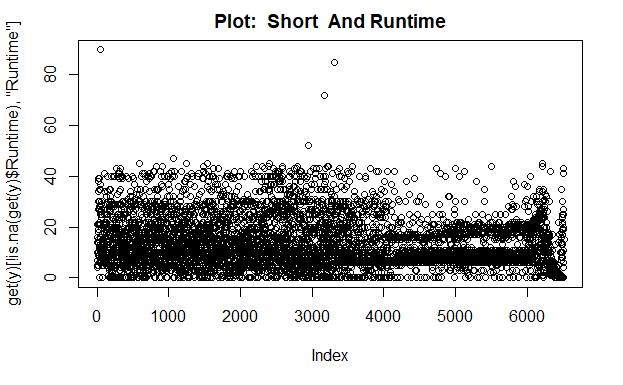

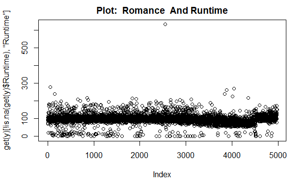

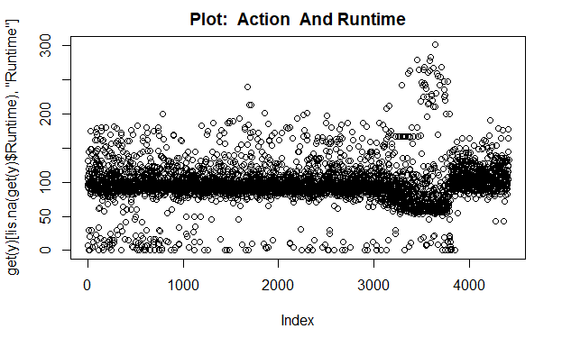

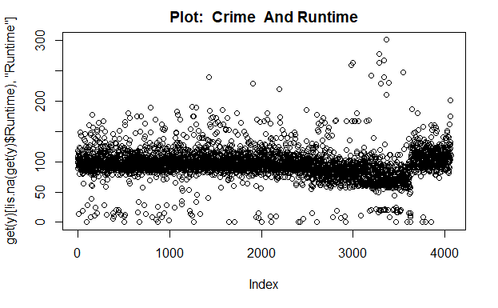

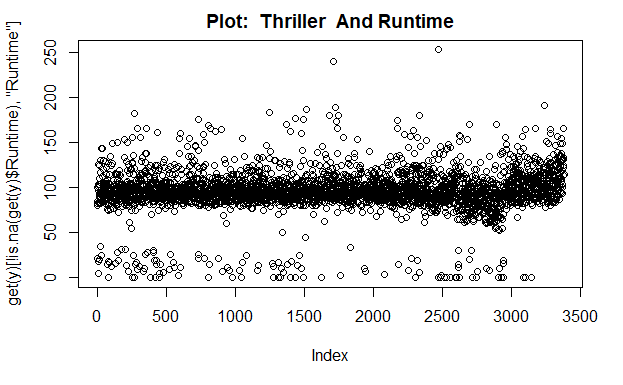

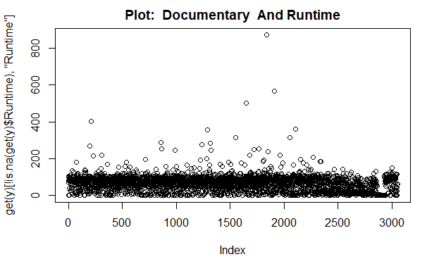

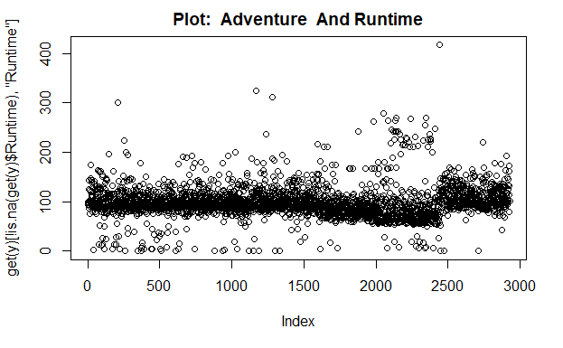

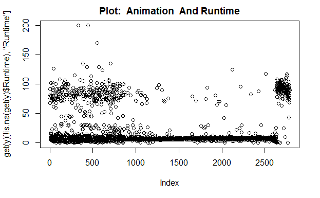

```r
# TODO: Plot Runtime distribution for top 10 most common genres
for (y in names(sorted[1:10]))
{
  assign(y, new_genre[new_genre[, y]==1,])

}
#assinging a dataframe consisting of each specific genre to each drama for easier plotting
for (y in names(sorted[1:10]))
{
  plot(get(y)[!is.na(get(y)$Runtime), "Runtime"], main = paste("Plot: ", y, " And Runtime"))

}
```

## 4. Eliminate mismatched rows

The dataframe was put together by merging two different sources of data and it is possible that the merging process was inaccurate in some cases (the merge was done based on movie title, but there are cases of different movies with the same title). There are 3 columns that contain date information: `Year` (numeric year), `Date` (numeric year), and `Released` (string representation of the release date).

Find and remove all rows where you suspect a merge error occurred based on a mismatch between these variables. To make sure subsequent analysis and modeling work well, avoid removing more than 10% of the rows that have a `Gross` value present.

*Note: Do not remove the rows with `Gross == NA` at this point, just use this a guideline.*

```r
# TODO: Remove rows with Year/Date/Released mismatch
time_df <- data.frame(new_genre$Title, new_genre$Year, new_genre$Released, new_genre$Date, new_genre$Gross)
df3 <- new_genre
df3$Released = as.Date(df3$Released, "%Y-%m-%d")
df3$Year_of_Release = as.numeric(format(df3$Released, "%Y"))
bad_data <- df3[(df3$Year == df3$Year_of_Release) | ((df3$Year + 1) == df3$Year_of_Release),]
before = length(df3$Gross[!is.na(df3$Gross)])
after = length(bad_data$Gross[!is.na(bad_data$Gross)])
percentage = ((before - after)/after) * 100
```

## 5. Explore `Gross` revenue

For the commercial success of a movie, production houses want to maximize Gross revenue. Investigate if Gross revenue is related to Budget, Runtime or Genre in any way.

*Note: To get a meaningful relationship, you may have to partition the movies into subsets such as short vs. long duration, or by genre, etc.*

```r
# TODO: Investigate if Gross Revenue is related to Budget, Runtime or Genre
gross_revenue = subset(new_genre, !is.na(new_genre$Gross))
gross_revenue <- gross_revenue[gross_revenue$Gross != 0, ]
summary(new_genre$Runtime)
```

```
   Min. 1st Qu.  Median    Mean 3rd Qu.    Max.
   0.00   69.00   90.00   80.26  100.00  873.00
```

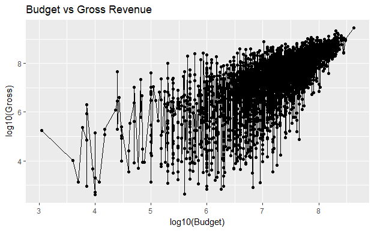

```r
small_runtime = subset(gross_revenue, gross_revenue$Runtime < 69) #1st quartile value
long_runtime = subset(gross_revenue, gross_revenue$Runtime > 100) #3rd quartile value
ggplot(gross_revenue, aes(x = log10(Budget), y = log10(Gross))) + geom_point() + geom_line() + ggtitle("Budget vs Gross Revenue")
```

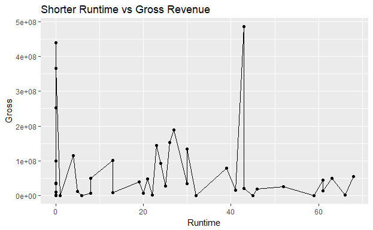

```r
ggplot(small_runtime, aes(Runtime, Gross)) + geom_point() + geom_line() + ggtitle("Shorter Runtime vs Gross Revenue")
```

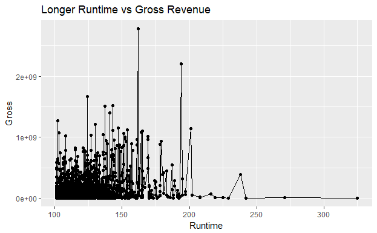

```r
ggplot(long_runtime, aes(Runtime, Gross)) + geom_point() + geom_line() + ggtitle("Longer Runtime vs Gross Revenue")
```

**Q**: Did you find any observable relationships or combinations of Budget/Runtime/Genre that result in high Gross revenue? If you divided the movies into different subsets, you may get different answers for them - point out interesting ones.

I then divided the movies based on runtime namely, runtime < 69 and runtime > 100. (The first and third quartiles repectively). Icould obtain no solid evidence or enough facts about the relationship between gross revenue and shorter film run times.

Below, we can see the relationship between the gross revenue and the releae month. From the chart, it is observed that it will be most profitable to release a movie in the month of June and would also bring in good profits during the months of December, July, May, November. Some of the least profitable months would be September and April.

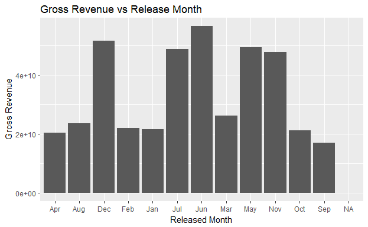

```r
# TODO: Investigate if Gross Revenue is related to Release Month
release_month <- month(as.POSIXct(bad_data$Released, format = "%y-%m-%d"))
bad_data$release_month <- month.abb[release_month]
ggplot(bad_data, aes(bad_data$release_month, bad_data$Gross)) +
  geom_bar(stat = "identity") + xlab("Released Month") + ylab("Gross Revenue") +
  ggtitle("Gross Revenue vs Release Month")
```

## 6. Process `Awards` column

The variable `Awards` describes nominations and awards in text format. Convert it to 2 numeric columns, the first capturing the number of wins, and the second capturing nominations. Replace the `Awards` column with these new columns, and then study the relationship of `Gross` revenue with respect to them.

*Note: The format of the `Awards` column is not standard; you may have to use regular expressions to find the relevant values. Try your best to process them, and you may leave the ones that don’t have enough information as NAs or set them to 0s.*

```r
# TODO: Convert Awards to 2 numeric columns: wins and nominations
for (a in c(1:nrow(new_genre)))
{
  aw1 = 0
  aw2 = 0
  if(grepl("Won", new_genre[a, "Awards"])) {
    aw1=as.numeric(str_extract(str_extract(new_genre[a,"Awards"], "Won ([\\d]+)"), "[[:digit:]]+"))
    aw1=aw1+as.numeric(str_extract(str_extract(new_genre[a,"Awards"], "([\\d]+) win"), "[[:digit:]]+"))
    aw2=aw2+as.numeric(str_extract(str_extract(new_genre[a,"Awards"], "([\\d]+) nomination"), "[[:digit:]]+"))
  }
  else if(grepl("Nominated",new_genre[a, "Awards"])){
    aw2=as.numeric(str_extract(str_extract(new_genre[a,"Awards"], "Nominated for ([\\d]+)"), "[[:digit:]]+"))
    aw1=aw1+as.numeric(str_extract(str_extract(new_genre[a,"Awards"], "([\\d]+) win"), "[[:digit:]]+"))
    aw2=aw2+as.numeric(str_extract(str_extract(new_genre[a,"Awards"], "([\\d]+) nomination"), "[[:digit:]]+"))
  }
  else{
    aw1=aw1+as.numeric(str_extract(str_extract(new_genre[a,"Awards"], "([\\d]+) win"), "[[:digit:]]+"))
    aw2=aw2+as.numeric(str_extract(str_extract(new_genre[a,"Awards"], "([\\d]+) nomination"), "[[:digit:]]+"))
  }
    new_genre[a,"wins"]=aw1
    new_genre[a, "nominations"]=aw2
    if(is.na(new_genre[a,"wins"])){new_genre[a,"wins"]=0}
    if(is.na(new_genre[a,"nominations"])){new_genre[a,"nominations"]=0}
  }
```

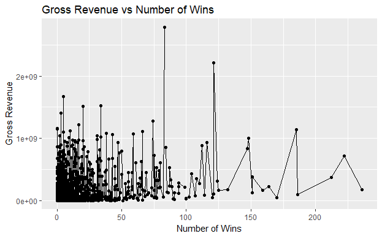

```r
# TODO: Plot Gross revenue against wins and nominations
ggplot(new_genre, aes(x = wins, y = Gross)) + geom_point() + geom_line() + ggtitle("Gross Revenue vs Number of Wins") + xlab("Number of Wins") + ylab("Gross Revenue")
```

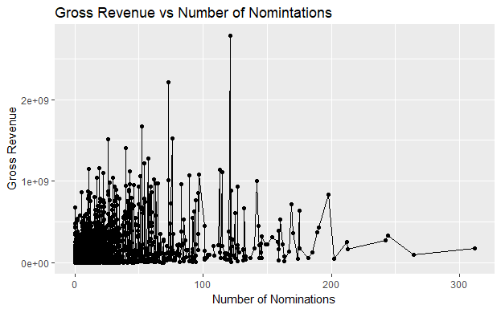

```r
ggplot(new_genre, aes(x = nominations, y = Gross)) + geom_point() + geom_line() + ggtitle("Gross Revenue vs Number of Nomintations") + xlab("Number of Nominations") + ylab("Gross Revenue")
```

## 7. Movie ratings from IMDb and Rotten Tomatoes

There are several variables that describe ratings, including IMDb ratings (`imdbRating` represents average user ratings and `imdbVotes` represents the number of user ratings), and multiple Rotten Tomatoes ratings (represented by several variables pre-fixed by `tomato`). Read up on such ratings on the web (for example rottentomatoes.com/about and www.imdb.com/help/show_leaf?votestopfaq).

Investigate the pairwise relationships between these different descriptors using graphs.

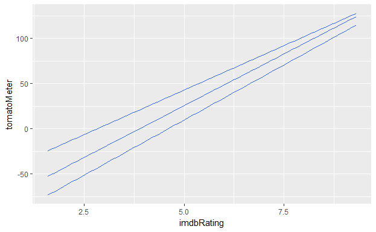

```r
# TODO: Illustrate how ratings from IMDb and Rotten Tomatoes are related
ggplot(new_genre, aes(x = imdbRating, y = tomatoMeter)) + geom_quantile()
```

[output not shown]

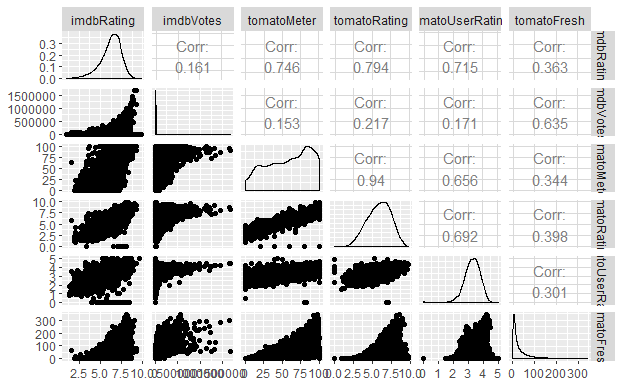

```r
ggpairs(new_genre[,c("imdbRating", "imdbVotes", "tomatoMeter", "tomatoRating", "tomatoUserRating", "tomatoFresh")])
```

**Q**: Comment on the similarities and differences between the user ratings of IMDb and the critics ratings of Rotten Tomatoes.

**A**: IMDB uses 2 separate ratings: ‘imdbrating’ and ‘imdbvotes’ Rotten tomatoes however uses 4 different ratings: ‘tomatometer’, ‘tomatofresh’, ‘tomatorating’ and ‘tomatouserratings’ The pairs graph can be seen above. It can be discerned that there is a high correlation between the ratings. Imdb does not have any self correlation whereas, the opposite can be said about Rotten tomatoes(which has a much stronger self correlation). The least correlation is observed between tomatoMeter and imdbVotes. However, the main similarity both ratings share is that they are centralized over a range of rating scores.

## 8. Ratings and awards

These ratings typically reflect the general appeal of the movie to the public or gather opinions from a larger body of critics. Whereas awards are given by professional societies that may evaluate a movie on specific attributes, such as artistic performance, screenplay, sound design, etc.

Study the relationship between ratings and awards using graphs (awards here refers to wins and/or nominations).

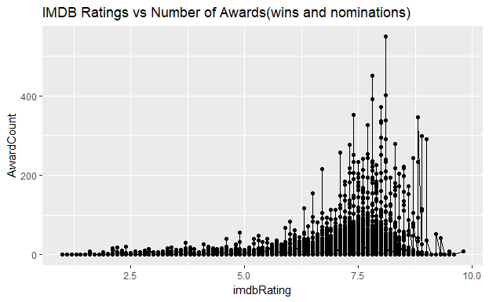

```r
# TODO: Show how ratings and awards are related
new_genre$AwardCount <- new_genre$wins + new_genre$nominations
ggplot(new_genre, aes(x = imdbRating, y = AwardCount)) + geom_point() + geom_line() + ggtitle("IMDB Ratings vs Number of Awards(wins and nominations)")
```

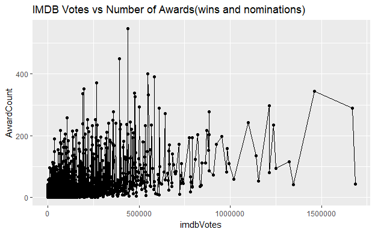

```r
ggplot(new_genre, aes(x = imdbVotes, y = AwardCount)) + geom_point() + geom_line() + ggtitle("IMDB Votes vs Number of Awards(wins and nominations)")
```

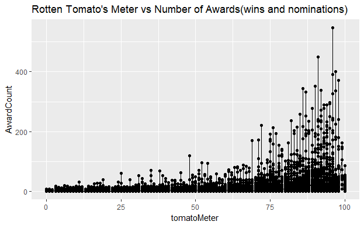

```r
ggplot(new_genre, aes(x = tomatoMeter, y = AwardCount)) + geom_point() + geom_line() + ggtitle("Rotten Tomato's Meter vs Number of Awards(wins and nominations)")
```

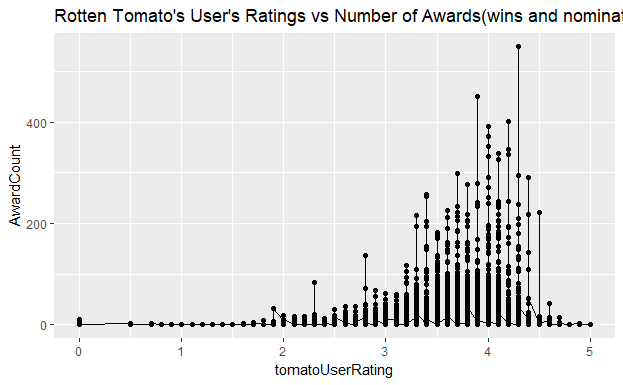

```r
ggplot(new_genre, aes(x = tomatoUserRating, y = AwardCount)) + geom_point() + geom_line() + ggtitle("Rotten Tomato's User's Ratings vs Number of Awards(wins and nominations)")
```

## 9. Expected insights

Come up with two new insights (backed up by data and graphs) that is expected. Here ânewâ means insights that are not an immediate consequence of one of the above tasks. You may use any of the columns already explored above or a different one in the dataset, such as `Title`, `Actors`, etc.

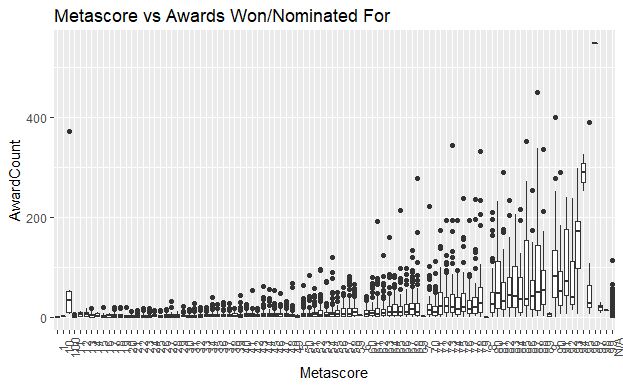

```r
# TODO: Find and illustrate two expected insights
#new_genre$Metascore[is.na(new_genre$Metascore)]
#INSIGHT1
#RELATIONSHIP BETWEEN METASCORE AND AWARD COUNT
ggplot(new_genre, aes(x = Metascore, y = AwardCount)) + geom_boxplot() +
  theme(axis.text.x = element_text(angle = 90)) + ggtitle("Metascore vs Awards Won/Nominated For")
```

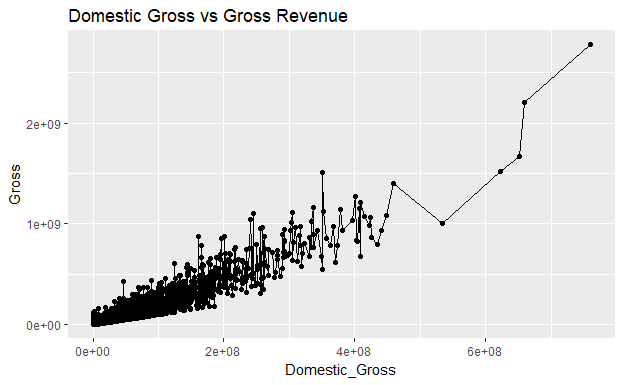

```r
#INSIGHT2
#RELATIONSHIP BETWEEN DOMESTIC GROSS AND  GROSS REVENUE
ggplot(new_genre, aes(x = Domestic_Gross, y = Gross)) + geom_point() + geom_line() + ggtitle("Domestic Gross vs Gross Revenue")
```

**Q**: Expected insight #1.

**A**: A relationship between Metascore and the total award count (win/nominations) is taken into affect above. As we can see clearly, there is some positive correlation between the two quantities leading us to the conclusion that the higher the metascore, the more number of awards will be won or nominated for. Due to the presence of some outliers, the relationship can’t be said as a strictly linear relationship. As we can clearly expect from the dataset, as the score keeps getting higher, the film will prove to be much more productive in terms of producing more revenue or even getting more awards, etc.

**Q**: Expected insight #2.

**A**: At a single glance at the graph between the domestic gross and the gross revenue, we can see that it is a pure linear relationship with a high positive correlation. Also tells us something around the lines of as the domestic gross revenue for a film increases, so will the total gross revenue, which is already a known fact to us.

## 10. Unexpected insight

Come up with one new insight (backed up by data and graphs) that is unexpected at first glance and do your best to motivate it. Same instructions apply as the previous task.

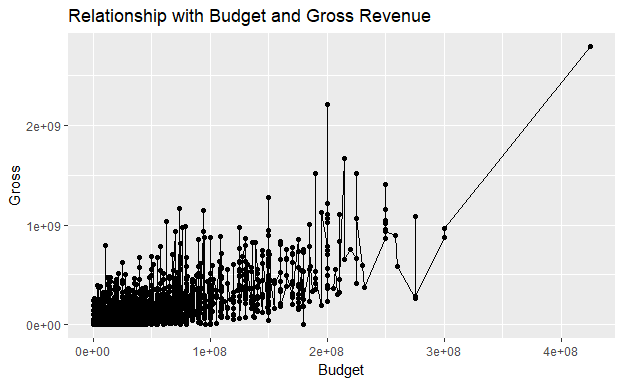

```r
# TODO: Find and illustrate one unexpected insight
ggplot(new_genre, aes(x = Budget, y = Gross)) + geom_point() + geom_line() + ggtitle("Relationship with Budget and Gross Revenue")
```

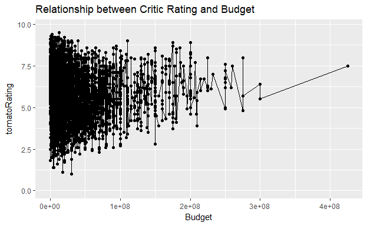

```r
ggplot(new_genre, aes(x = Budget, y = tomatoRating)) + geom_point() + geom_line() + ggtitle("Relationship between Critic Rating and Budget")
```

**Q**: Unexpected insight.